# WDAD Projekt Bartlomiej Ortyl

Bartlomiej Ortyl

30 01 2021

## Wprowadzenie

W moim projekcie badam zależnosci miedzy typem rodzin, liczba mieszkancow gospodarstw, regionem zamieszkania, a alkoholem. Postawilem 5 hipotez, ktore nastepnie sprawdzilem za pomoca jezyka R. Wybralem alkohol, poniewaz te wlasnie testy wydawaly mi sie najciekawsze do sprawdzenia oraz chcialem sprawdzic kulture picia w tym kraju oraz czy cos co sie moze wydawac jest faktycznie prawda.

HIPOTEZY  
H1: Grupa 1 rozni sie od grupy 2 wydatkami na alkohol  
H2: Osoby samotne poniżej 35 lat wydaj wiecej na alkohol niż osoby samotne powyzej 35 lat  
H3: W veneto, czyli w stolicy winiarstwa we wloszech wydaje sie wiecej na wino niz w innych regionach  
H4: Im mniej osób w gospodarstwie domowym tym wiecej sie wydaje na alkohol(na 1 czlonka rodziny)  
H5: Osoby, które wydaja wiecej niz srednia na alkohole luksusowe wydaje mniej na wino i piwo

## Przygotowanie danych do badania

```r
library(ggplot2)
dane<-read.table("HBS_Microdati_Anno_2011.txt", header=T, sep="\t")
dane1<-dane[, c("TIPFAM", "NC", "Regione", "C_1803", "C_1804", "C_1805")]
```

Z surowych danych wyciagnalem tylko te ktore sa potrzebne do mojego projektu.

## Opis bazy danych

```r
table(dane1$TIPFAM)
```

```
##
##    1    3    4    6    7    8   10
## 3206 3145 2001 2818 3876 4676 3352
```

Jak widzimyw naszej bazie nie ma typu rodzin z numerem 2 czyli osob samotnych w wieku 35-64 lat, oraz nie ma typu numer 5 czyli Par bez dzieci z osobą kontaktową w wieku 35-64 la, nie ma rowniez numeru 9 czyli para z 3 i więcej dziećmi.

```r
table(dane1$NC)
```

```
##
##    1    2    3    4    5    6
## 6351 6520 4770 4094 1126  213
```

W powyższej tabeli widzimy, rozklad ilosci mieszkancow na jedno gospodarstwo domowe, mozemy zauwazyc, że najwiecej jest gospodarstw z 2 osobami.

```r
table(dane1$Regione)
```

```
##
##    1    3    4    5    6    7    8    9   10   11   12   13   14   15   16   17
## 2103 2423 1226 1494  777 1024 1358 1341  720  851 1317  621  707 1673 1335  649
##   18   19   20
## 1023 1644  788
```

Powyzej przedstawiona jest tabela regionow we wloszech i ilosci mieszkancow w kazdym z nich, najwiecej badanych pochodzi z Lombardii.

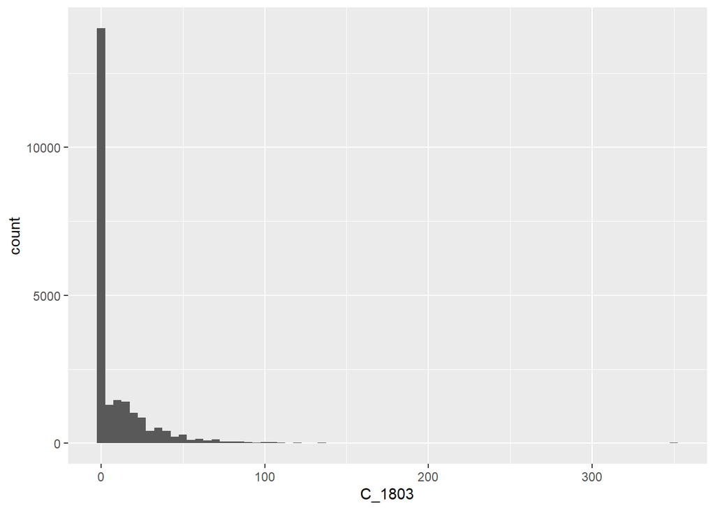

```r
ggplot(dane1, aes(x=C_1803))+geom_histogram(binwidth=5)
```

Powyzszy historam przedstawia wydatki na wino z badanych gospodarstw, mozemy latwo zauwazyc ze wiekszosc gospodarstw nie wydaje nic na wino.

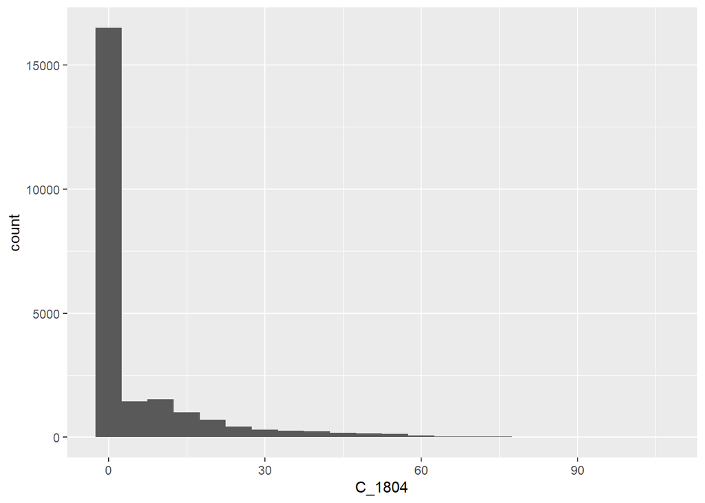

```r
ggplot(dane1, aes(x=C_1804))+geom_histogram(binwidth=5)
```

Powyzszy historam przedstawia wydatki na piwo z badanych gospodarstw, mozemy latwo zauwazyc ze wiekszosc gospodarstw nie wydaje nic na piwo.

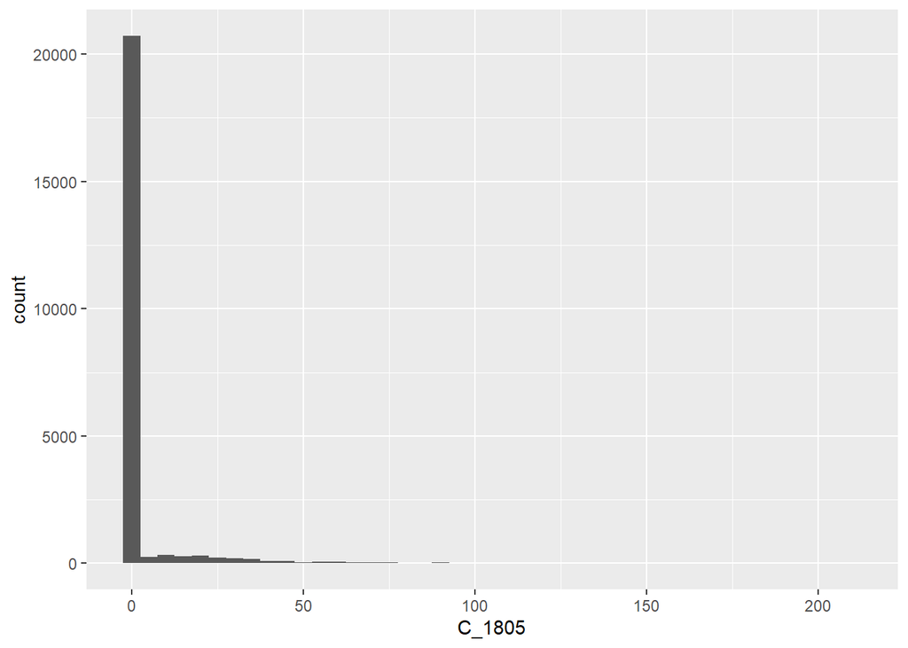

```r
ggplot(dane1, aes(x=C_1805))+geom_histogram(binwidth=5)
```

Powyzszy historam przedstawia wydatki na Likiery, szampan i aperitify alkoholowe z badanych gospodarstw, mozemy latwo zauwazyc ze wiekszosc gospodarstw nie wydaje nic na Likiery, szampan i aperitify alkoholowe.

```r
summary(dane1$C_1803)
```

```
##    Min. 1st Qu.  Median    Mean 3rd Qu.    Max.
##    0.00    0.00    0.00   11.67   14.22  351.05
```

Srednie wydatki na wino to 11.67.

```r
summary(dane1$C_1804)
```

```
##    Min. 1st Qu.  Median    Mean 3rd Qu.    Max.
##   0.000   0.000   0.000   5.528   5.870 102.710
```

Srednie wydatki na piwo to 5.528.

```r
summary(dane1$C_1805)
```

```
##    Min. 1st Qu.  Median    Mean 3rd Qu.    Max.
##   0.000   0.000   0.000   3.623   0.000 209.460
```

Srednie wydatki na Likiery, szampan i aperitify alkoholowe to 3.623.

# Hipotezy

## HIPOTEZA 1

## Pary bez dzieci wydaja wiecej na alkohol niz pary z dziecmi

```r
dane1$grupa<-NA
dane1$grupa[dane1$TIPFAM=="4"] <-0
dane1$grupa[dane1$TIPFAM=="6"] <-0
dane1$grupa[dane1$TIPFAM=="7"] <-1
dane1$grupa[dane1$TIPFAM=="8"] <-1
dane1$sumaalkohol<-dane1$C_1803+dane1$C_1804+dane1$C_1805
```

Tworze nowa zmienna dzielaca grupy z dziecmi od grup bez dzieci, przypisujac im 0(bez dzieci) lub 1(z dziecmi).  
Nastepnie tworze kolejna zmienna sumaalkohol aby zsumowac wszystkie wydatki na alkohol dla kazdego gospodarstwa.

```r
mean(dane1$sumaalkohol[dane1$grupa=="0"], na.rm=TRUE)
```

```
## [1] 23.94084
```

```r
mean(dane1$sumaalkohol[dane1$grupa=="1"], na.rm=TRUE)
```

```
## [1] 23.64563
```

Jak widzimy srednie dla obydwu grup sa bardzo zblizone, ale z minimalnymi wiekszymi wydatkami grupy bez dzieci co potwierdza moja hipoteze.  
Sprawdze jeszcze srednie dla kazdego rodzaju badanego alkoholu odzielnie.

```r
mean(dane1$C_1803[dane1$grupa=="0"], na.rm=TRUE)
```

```
## [1] 15.2068
```

```r
mean(dane1$C_1803[dane1$grupa=="1"], na.rm=TRUE)
```

```
## [1] 12.78347
```

Jak widac grupa bez dzieci wydaje wiecej na wino.

```r
mean(dane1$C_1804[dane1$grupa=="0"], na.rm=TRUE)
```

```
## [1] 5.117867
```

```r
mean(dane1$C_1804[dane1$grupa=="1"], na.rm=TRUE)
```

```
## [1] 6.75616
```

Natomiast grupa z dziecmi wydaje wiecej na piwo.

```r
mean(dane1$C_1805[dane1$grupa=="0"], na.rm=TRUE)
```

```
## [1] 3.616171
```

```r
mean(dane1$C_1805[dane1$grupa=="1"], na.rm=TRUE)
```

```
## [1] 4.106007
```

Grupa z dziecmi wydaje rowniez nieco wiecej na alkohole luksusowe.

## HIPOTEZA 2

## Osoby samotne poniżej 35 lat wydaj wiecej na alkohol niż osoby samotne powyzej 35 lat

```r
mean(dane1$sumaalkohol[dane1$TIPFAM=="1"], na.rm=TRUE)
```

```
## [1] 18.73249
```

```r
mean(dane1$sumaalkohol[dane1$TIPFAM=="3"], na.rm=TRUE)
```

```
## [1] 11.83877
```

Jako ze w mojej bazie nie ma typu rodziny 2, czyli osoba samotna w wieku 35-64 lat, to uwzgledniam tylko grupy 1 oraz 3 i licze ich srednie wydatki na alkohol.  
Srednie potwierdzaja moja hipoteze, osoby samotne ponizej 35 lat wydaja wiecej na alkohol.

Ponizej porownuje rowniez te 2 grupy na osobnych rodzajach alkoholu.

```r
mean(dane1$C_1803[dane1$TIPFAM=="1"], na.rm=TRUE)
```

```
## [1] 8.843253
```

```r
mean(dane1$C_1803[dane1$TIPFAM=="3"], na.rm=TRUE)
```

```
## [1] 6.952143
```

Mlodsze osoby samotne wydaja wiecej na wino.

```r
mean(dane1$C_1804[dane1$TIPFAM=="1"], na.rm=TRUE)
```

```
## [1] 6.193107
```

```r
mean(dane1$C_1804[dane1$TIPFAM=="3"], na.rm=TRUE)
```

```
## [1] 2.130251
```

Samotne osoby ponizej 35 lat wydaja niemal 3 krotnie wiecej na piwo !

```r
mean(dane1$C_1805[dane1$TIPFAM=="1"], na.rm=TRUE)
```

```
## [1] 3.696132
```

```r
mean(dane1$C_1805[dane1$TIPFAM=="3"], na.rm=TRUE)
```

```
## [1] 2.756375
```

Jak mozna sie bylo spodziewac alkohole luksusowe rowniez czesciej goszcza u osob samotnych mlodszych.

## HIPOTEZA 3

## W veneto, czyli w stolicy winiarstwa we wloszech wydaje sie wiecej na wino niz w innych regionach

```r
srednie_wino<-aggregate(dane1$C_1803, by=list(dane1$Regione), FUN=mean)
srednie_wino
```

```
##    Group.1         x
## 1        1 15.558564
## 2        3 14.440962
## 3        4  8.837194
## 4        5 12.155033
## 5        6 11.201326
## 6        7 14.519307
## 7        8 15.512916
## 8        9 14.893453
## 9       10 10.410111
## 10      11 12.577192
## 11      12 10.940190
## 12      13 10.107295
## 13      14  9.984583
## 14      15 10.003808
## 15      16  8.751483
## 16      17  9.717519
## 17      18  8.709120
## 18      19  6.366229
## 19      20 10.163655
```

Wyliczam srednie wydatki na wino w kazdym badanym regionie.  
Okazalo sie ze Veneto mimo ze jest w czolowce to nie wydaje sie tam najwiecej na wino. Nie potwierdza to mojej hipotezy.

Najwiecej czerwonego trunku przelewa sie w Piemont i Valle d’Aosta.  
Ponizszy wykres przedstawia wydatki dla kazdego regionu po kolei.

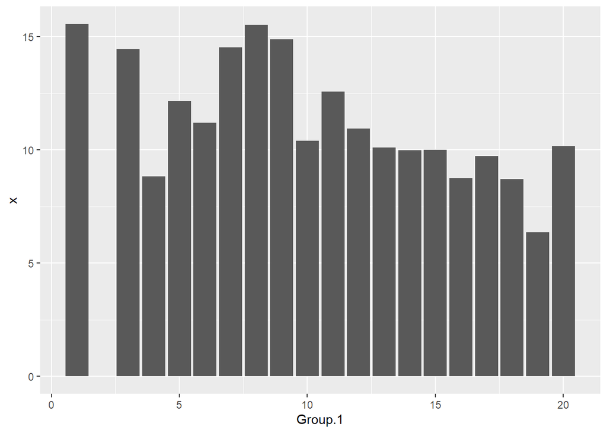

```r
ggplot(srednie_wino, aes(x=Group.1, y=x))+geom_col()
```

## HIPOTEZA 4

## Im mniej osób w gospodarstwie domowym tym wiecej sie wydaje na najbardziej przystepny alkohol we wloszech czyli wino(na 1 czlonka rodziny)

```r
srednie_wino_NC<-aggregate(dane1$C_1803, by=list(dane1$NC), FUN=mean)
srednie_wino_NC
```

```
##   Group.1        x
## 1       1  7.90678
## 2       2 13.74678
## 3       3 13.17616
## 4       4 12.09638
## 5       5 13.14710
## 6       6 11.01239
```

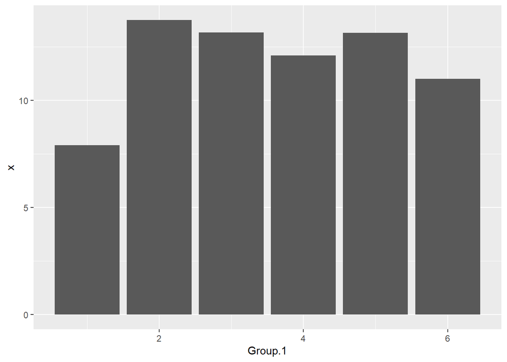

```r
ggplot(srednie_wino_NC, aes(x=Group.1, y=x))+geom_col()
```

Srednie oraz wykres zaprzeczaja mojej hipotezie.

```r
dane1$wino<-ifelse(dane1$C_1803>11.67, 1, 0)
regresja1<-glm(dane1$wino~dane1$NC, family="binomial")
summary(regresja1)
```

```
##
## Call:
## glm(formula = dane1$wino ~ dane1$NC, family = "binomial")
##
## Deviance Residuals:
##     Min       1Q   Median       3Q      Max
## -0.9842  -0.8423  -0.7555   1.4975   1.6693
##
## Coefficients:
##             Estimate Std. Error z value Pr(>|z|)
## (Intercept) -1.23492    0.03293  -37.50   <2e-16 ***
## dane1$NC     0.12700    0.01156   10.98   <2e-16 ***
## ---
## Signif. codes:  0 '***' 0.001 '**' 0.01 '*' 0.05 '.' 0.1 ' ' 1
##
## (Dispersion parameter for binomial family taken to be 1)
##
##     Null deviance: 27612  on 23073  degrees of freedom
## Residual deviance: 27491  on 23072  degrees of freedom
## AIC: 27495
##
## Number of Fisher Scoring iterations: 4
```

Tworze nowa zmienna dane1$wino i za pomoca ifelse dziele ja na 2 grupy, wyzsze od srednich wydatkow lub nizsze(1 - to duzy wynik, 0 - to maly wynik).

```r
exp(regresja1$coefficients)
```

```
## (Intercept)    dane1$NC
##   0.2908593   1.1354118
```

Uzywajac regresji logistycznej wyszedl nam jeden wspolczynnik(wiekszy niz 1) ktory mowi ze im wiecej osob w gospodarstwie, tym wieksza szansa na duze wydatki na wino.  
Zaprzecza to mojej hipotezie .

## HIPOTEZA 5

## Osoby, które wydaja wiecej niz srednia na alkohole luksusowe wydaje mniej na wino i piwo

```r
cor.test(dane1$C_1803, dane1$C_1805)
```

```
##
##  Pearson's product-moment correlation
##
## data:  dane1$C_1803 and dane1$C_1805
## t = 14.931, df = 23072, p-value < 2.2e-16
## alternative hypothesis: true correlation is not equal to 0
## 95 percent confidence interval:
##  0.08502814 0.11058724
## sample estimates:
##        cor
## 0.09782382
```

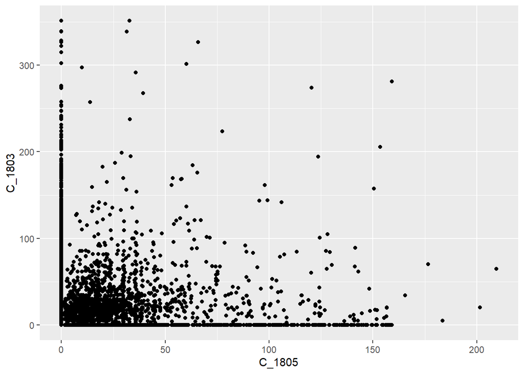

```r
ggplot(dane1, aes(y=C_1803, x=C_1805))+geom_point()
```

```r
cor.test(dane1$C_1804, dane1$C_1805)
```

```
##
##  Pearson's product-moment correlation
##
## data:  dane1$C_1804 and dane1$C_1805
## t = 13.028, df = 23072, p-value < 2.2e-16
## alternative hypothesis: true correlation is not equal to 0
## 95 percent confidence interval:
##  0.07263335 0.09825093
## sample estimates:
##        cor
## 0.08545626
```

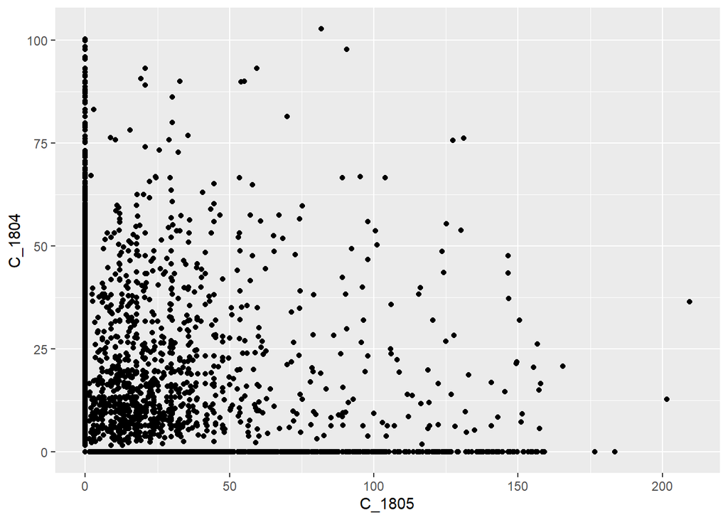

```r
ggplot(dane1, aes(y=C_1804, x=C_1805))+geom_point()
```

Utworzylem korelacje, ktora pokazala ze dla wina i piwa wspolczynniki korelacji(0.09782382, 0.08545626) wyszly dodatnie, czyli jesli wydajemy wiecej na alkohole luksusowe, wydajemy rowniez wiecej na inne alkohole co zaprzecza mojej hipotezie. p < 0,05 - istotny zwiazek, ale dodatni, nie ujemny - czyli im wyzsze wydatki na wino i piwo, tym wieksze na likiery.

## PODSUMOWANIE

Podsumowujac, wedlug mnie we Wloszech nie ma zbyt wielu regul ani stereotypow jesli chodzi o picie alkoholu. Wedlug mnie kazdy pije tam jak chce i ile chce co jest piekne. Ciezko dopatrzec sie jakis wiekszych zaleznosci albo wyszukac niesamowitych korelacji.  
Hipoteza numer 1 i 2 zostaly przezemnie potwierdzone, natomiast hipotezy 3,4,5 zostaly zaprzeczone.  
Wlochy to piekny kraj bedaca w swiatowej czolowce jesli chodzi o wino. Kazdy kto tam przyjezdza musi sprobowac ich lokalnych trunkow. Sam osobiscie bylem we Wloszech raz i byly to niezapomniane wakacje, ktore kazdemu moge szczerze polecic.